# LondonBikeSharing

VigneshwarPesaru

3/12/2021

## R Source of Data:

https://www.kaggle.com/hmavrodiev/london-bike-sharing-dataset

The data is further acquired from 3 sources:

Https://cycling.data.tfl.gov.uk/ ‘Contains OS data © Crown copyright and database rights 2016’ and Geomni UK Map data © and database rights [2019] ‘Powered by TfL Open Data’ freemeteo.com - weather data https://www.gov.uk/bank-holidays From 1/1/2015 to 31/12/2016 The data from cycling dataset is grouped by “Start time”, this represent the count of new bike shares grouped by hour. The long duration shares are not taken in the count.

## R CoNVO statement

#CONTEXT:

The London based tech-startup company has established an innovative transportation business, whereby system subscribers have access to bicycles through self-service kiosk locations around the community. This London Bike sharing (LBS) company is providing the bike rentals for short distance point-to-point trips providing subscribers access to bicycles at any self-service bike station to use and return to any bike station within the system’s service area. Bike share stations are generally spaced in a dense grid pattern to create convenient origins and destinations for riders. Most UK operators record the average ride at 15 to 20 minutes and between one to four miles long. The bicycle can be returned to any number of self-serve bike sharing stations, including the original check out location. The rental transaction is fully automated and there is no need for on-site staff.

Recently, the Sr.Director of this company has passed an order to revive the revenue plans of the company. The company Research and Development(R&D) head is now started working with his team in trying to understand the impact of seasons, holidays, weather and peak times on their current existing business model. Based on these relationships, LBS company would like to adopt a new technology which helps them in investing on different technologies and ideas of promoting the rental business to increase the demand.

NEED:

Revenue is the most important key performance indicator of any company. A profitable business can be achieved either through cost cutting or through high marginal sales. Here the client is more interested in how to increase their rentals per hour ratio(ridership).

$$\ { ridership } = {TotalRides}/{ hour }$$

LBS has come up with a plan for increment in ridership throughout the year by providing promotional codes to new riders, discounts during the holidays/weekends, user friendly fares during the peak times etc., In-order to further invest on promotion codes to new riders, the Sr.Director is more interested in knowing the impact of seasons, holidays, weather and peak times on their current existing business model. Say for suppose, understanding the impact of seasons on the past and current ridership trend would provide the data evidence on whether to invest in the promotion codes to new riders are not. Similarly, understanding the impact of weekdays/weekends on the past and current ridership trend serves as the data evidence on whether to invest on Discounts during weekends or not. etc.,

In this way the inference of various factors on the rentals would help management team to come up with a decision on what is the best season to introduce promotion codes and discounts.

Here, LBS is not just looking at one single objective of prediction but it is more interested into finding out the inference of the problem such as understanding the effect seasonality patterns, weather, holiday and peak times on demand for bike sharing. Based on the established inferences from the potential predictors, client is ready to take any appropriate measures to make a profitable business in an year.

VISION:

The aim of the LBS is to develop an affordable, user-friendly bike share plan that increases ridership with the profitable business. The LBS envisions a system that is accessible and equitable to UK residents, students, workers and visitors.

The Bike Share Business Plan expands and revises adopted revenue policies. This plan introduces the following new concepts: 1. Basic tool for demand prediction and estimated revenues, 2. Understanding the impact of various factors (seasons, weather etc.,) on the performance indicators(ridership),  
3. New bike share technologies, 4. Demand prediction model further helps the management in whether to invest further in Promotional codes to new riders, discounts during weekends/holidays and user friendly fares during peak hours

OUTCOME:

Once the company director is happy with the preliminary results which basically provides the insights about their historical performance of their 2 years business. The company is willing to adapt this new tool for a minimum of 1 year of seasonality patterns to see any improvements in their key performance indicators which in-turn affects their ideas of investing such as, monthly or annual membership plans, promotional codes etc., The business manager closely monitors the key performance indicators includes such as:

1. % increment in riderships.
2. % increment in Quarter revenue.
3. Investment expenses for an year and reports directly to director every quarter.

## R Renaming the predictors names

## R Data Pre-processing

From the given data, we can identify that the following are the predictors:

## R DEFINATIONS AND DESCRIPTION:

PREDICTORS:

1. Timestamp : This is in the format of mm/dd/yyyy hh which tells us the information about the bike rents that were happened
2. Weather : The weather field in the data describes about the how the day is basically is it a sunny day or cloudy or rainy day etc.,
3. Temperature : The temperature field in the data is measured in the degrees of celsius scale. It is the average temperature measured during the day
4. Feels like temperature: The Feels like temperature field in the data is measured in the degrees of celsius scale. It is the average feels like temperature during the day.
5. Wind speed : This is the speed with which air is moving from high to low pressure, usually due to changes in temperature
6. Humidity : This is the field in data which indicates the concentration of water vapor present in the air.
7. Workday : This is just binary variable tells us the information about the day whether it is a workday or not
8. Season : The season variable in the data tells us the information about whether the season being spring, summer, fall or winter.

RESPONSE VARIABLE 1. Rentals : The response variable is the total number of rents that were occurred during any given hour of a given day

## R Total number of rentals based on the Years

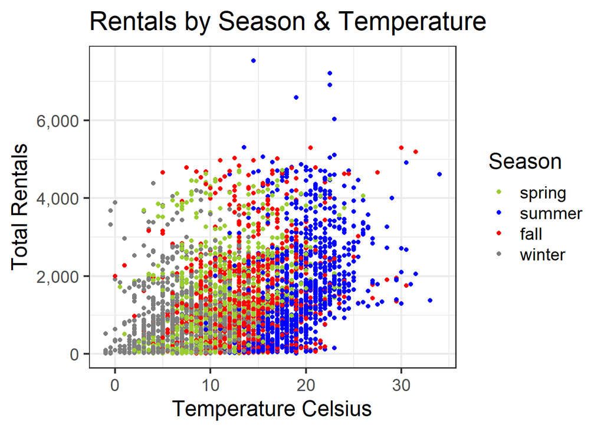

#Observation:

Clearly from the above 3 dimensional plot we can see that the rentals are happening summers are higher compared to rest of the seasons.This plot also concludes that number of rentals happened during 15-25 degree celsius are more in number than the rest of the temperature.

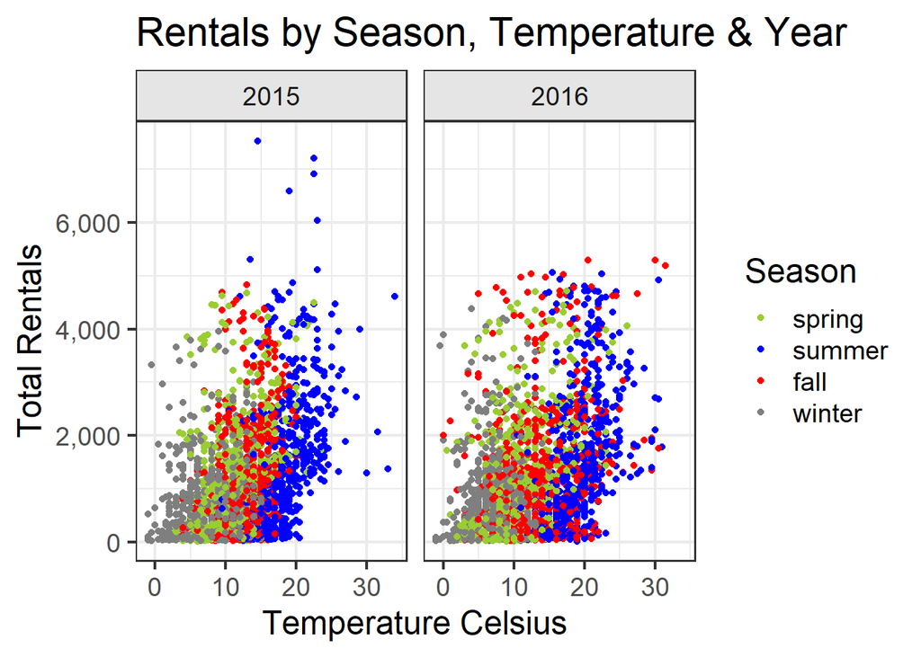

#Observation:

As I mentioned in the above plot, the number of rentals are happening in the summer are more in number in the both the historical years i.e. 2015 and 2016.

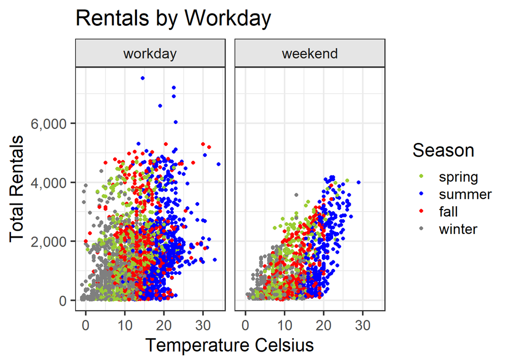

#Observation:

Clearly, from the above plot we can see that the number of rentals happening during the workdays are more in number when compared to the weekends.

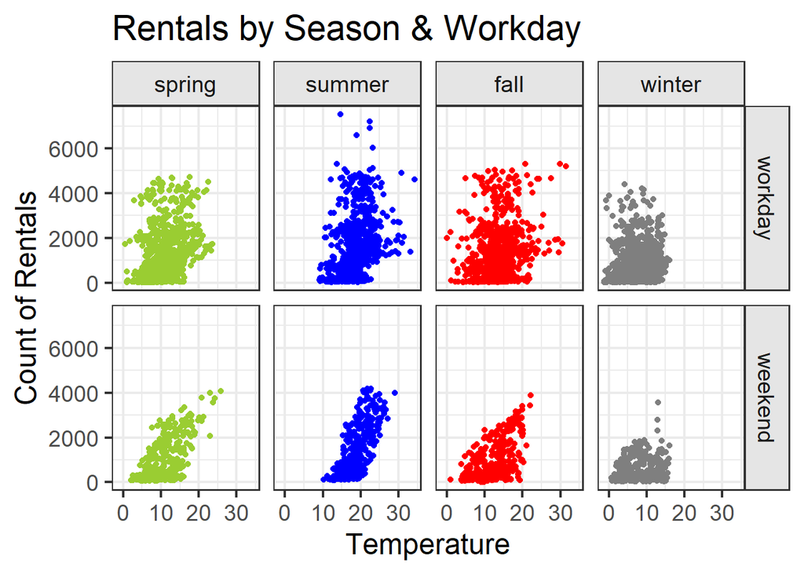

#Observation:

As I mentioned in my above plot from the above plot that the number of rentals happening during the workdays are more in number when compared to the weekends.And this trend is repeated across all the seasons.

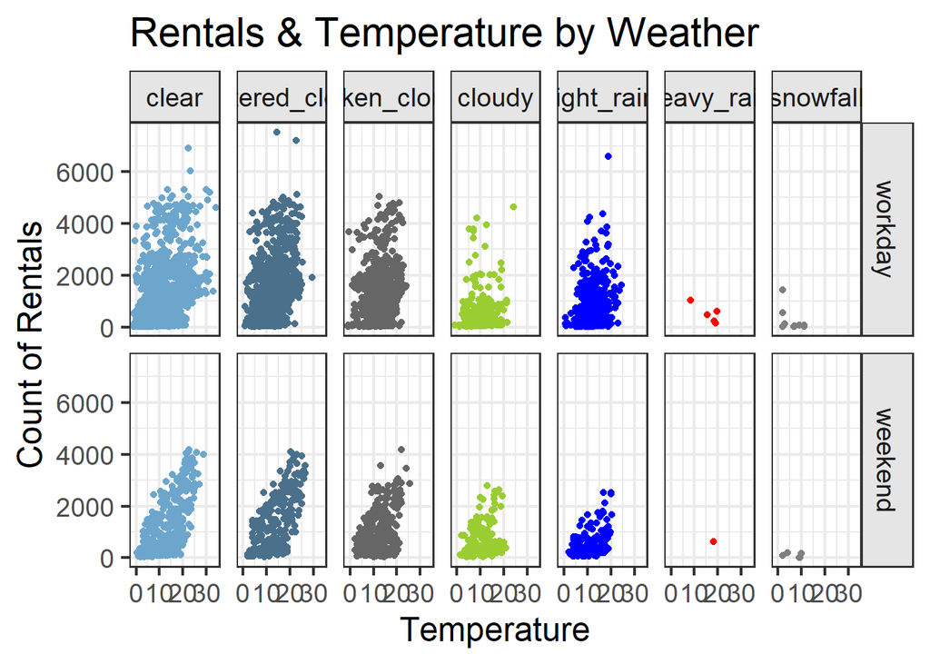

#Observation:

As I mentioned in my above plot from the above plot that the number of rentals happening during the workdays are more in number when compared to the weekends.And this trend is repeated across all the different types of weather.

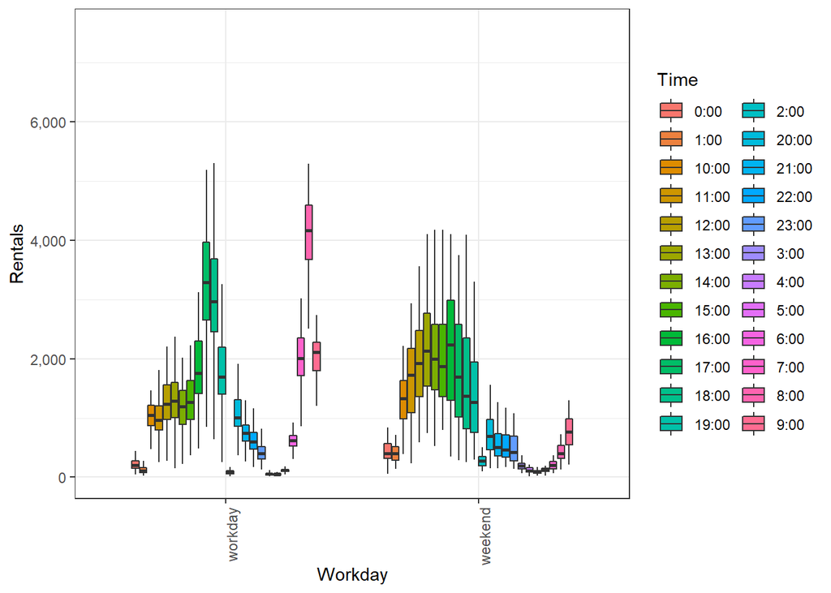

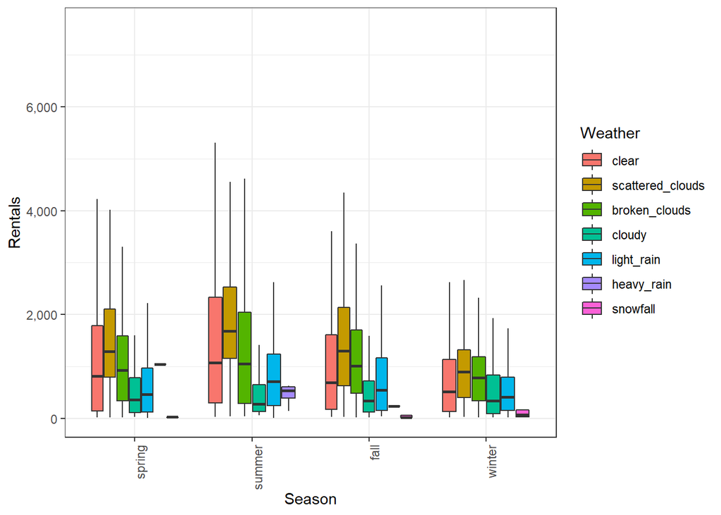

#————————————————————-# ### Data Distributions - Is data normally distributed? #### #————————————————————-# ###############################################################

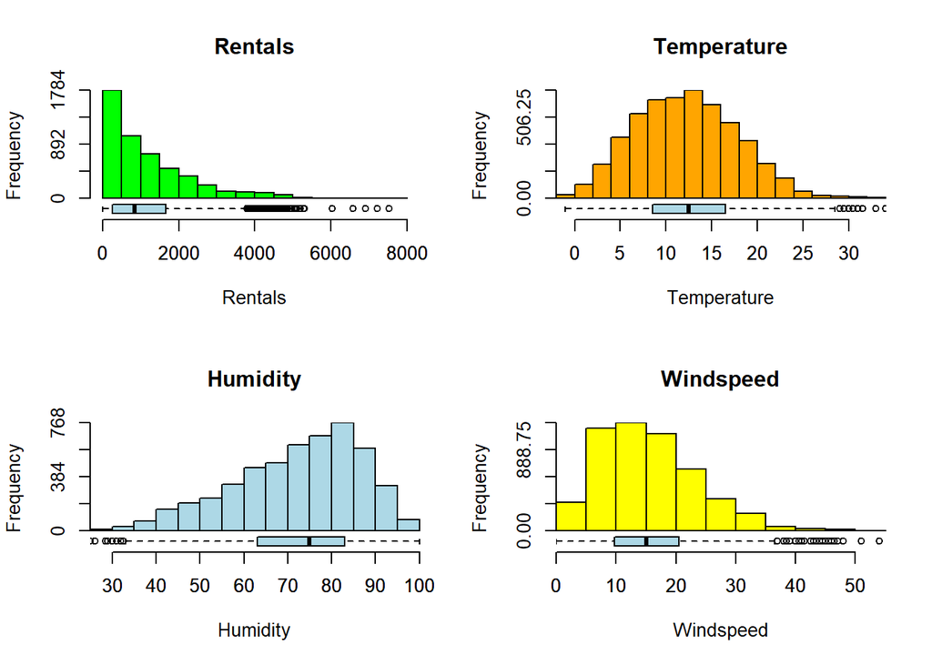

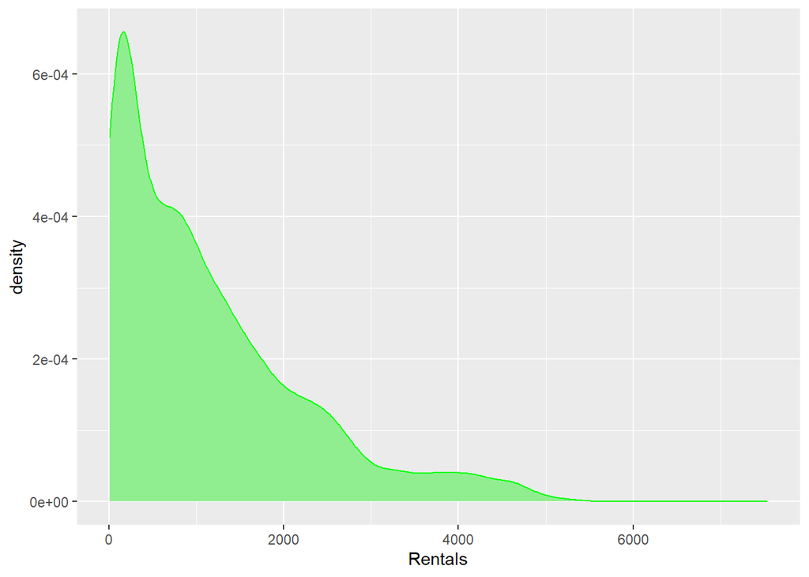

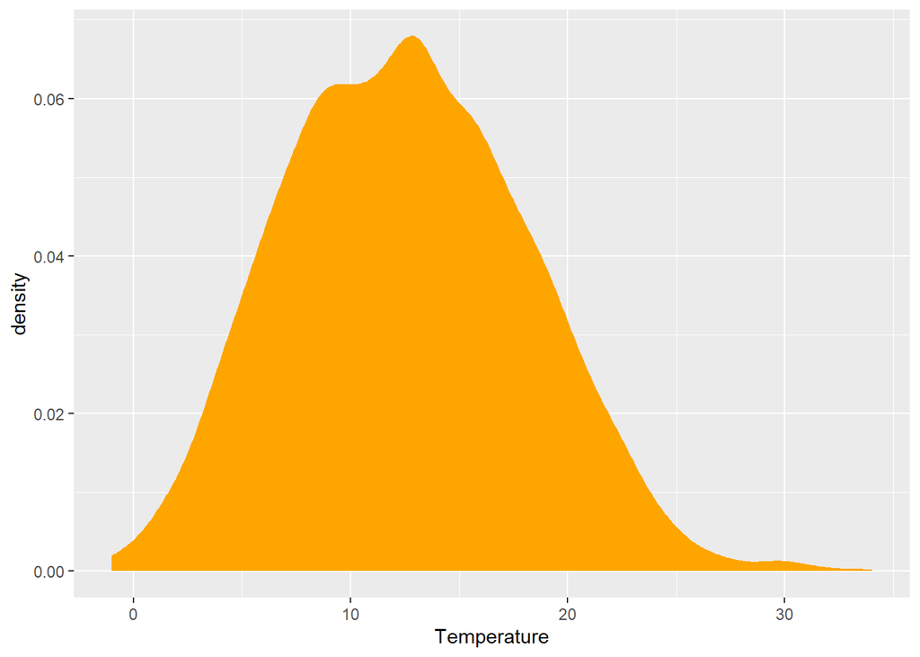

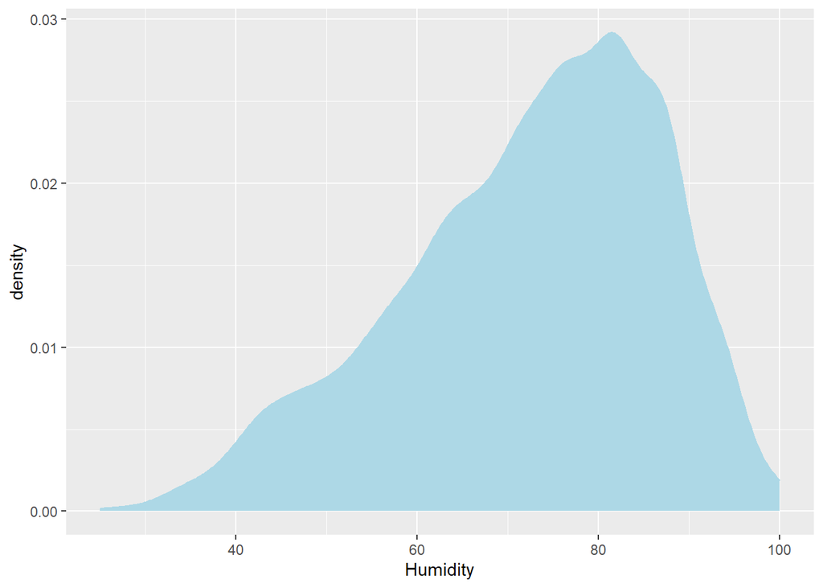

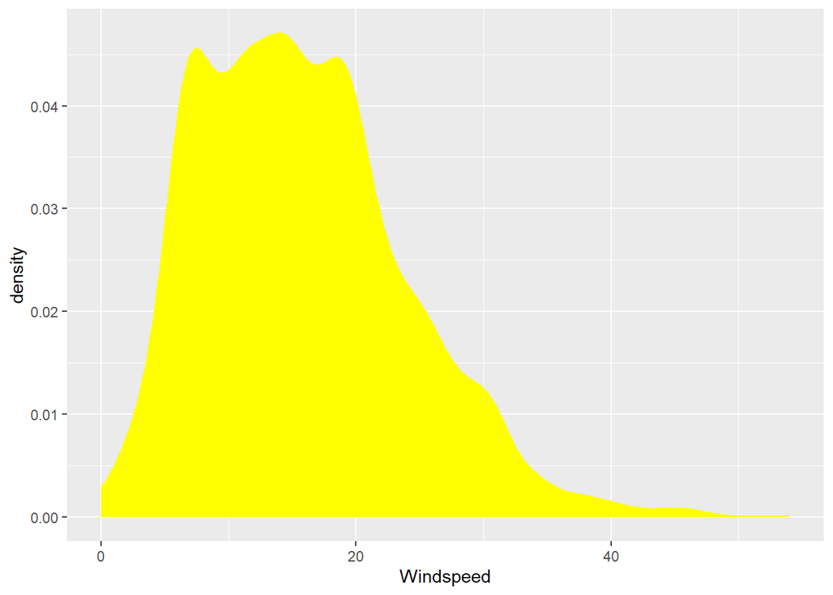

```
## [1] 1.37346
```

```
## [1] 0.2061145
```

```
## [1] -0.5640249
```

```
## [1] 0.6844815
```

#Observation:

Clearly from the histogram frequency plot and from the density plots we can see the outcome variable “RENTALS” is positively skewed with the value 1.37.

To remove the positive skewness, I have applied the log-transformation to the outcome variable.And further to it, I have applied the batch transformation to the predictors.

```
## [1] 1.37346
```

```
## [1] -0.615923
```

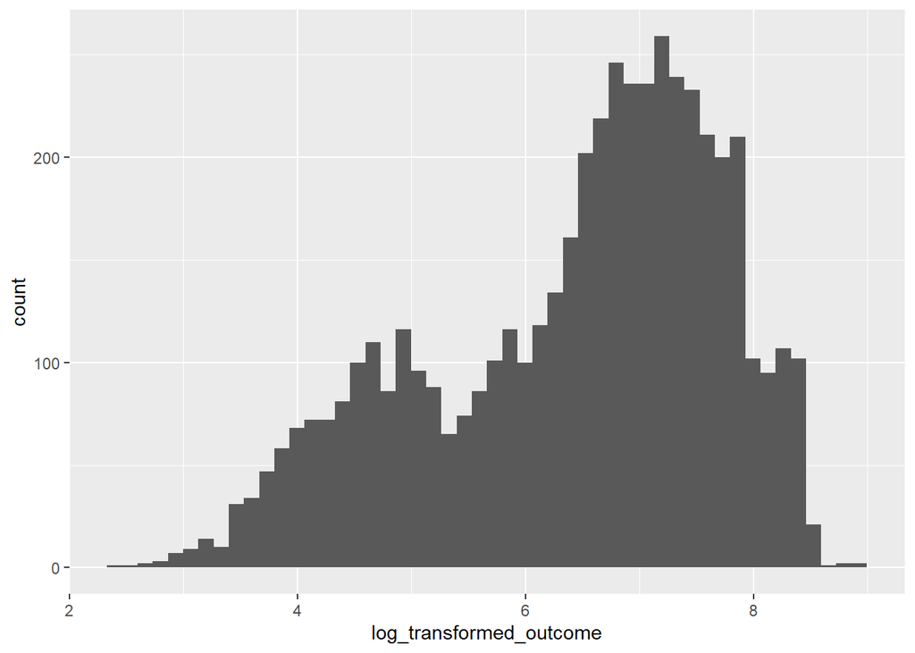

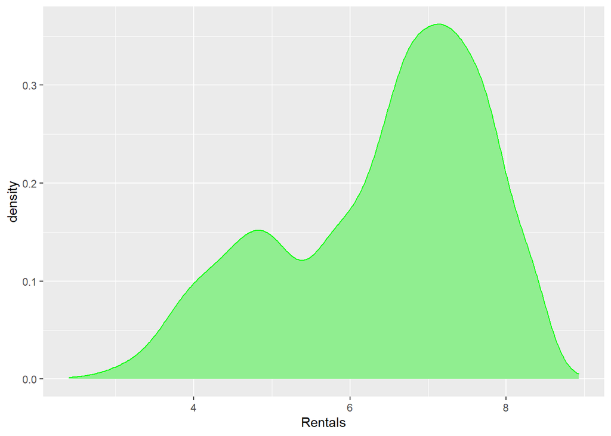

#Observation: After applying the log-transformation, we could see that the outcome variable “Rental” is now with the skewness -0.62

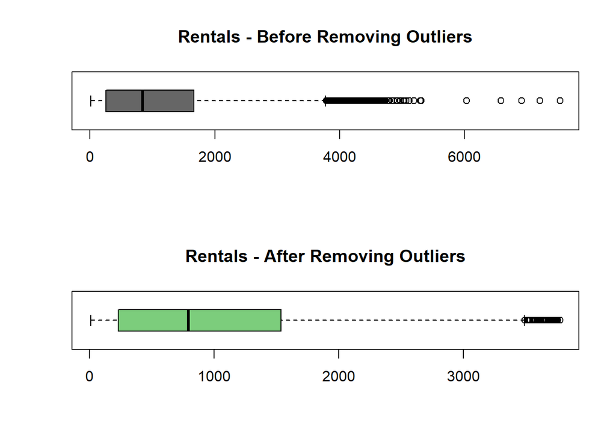

```
## [1] 200
```

```
##   Rentals Time Workday DayNumberinMonth Temperature Humidity Weather Season
## 1       0    0       0                0           0        0       0      0
##   Windspeed
## 1         0
```

#Null Hypothesis Rejection

```
##
## Call:
## lm(formula = Rentals ~ Temperature, data = train.data)
##
## Residuals:
##     Min      1Q  Median      3Q     Max
## -1529.1  -590.0  -163.7   419.2  3494.3
##
## Coefficients:
##             Estimate Std. Error t value Pr(>|t|)
## (Intercept)  218.624     32.576   6.711 2.21e-11 ***
## Temperature   63.848      2.414  26.454  < 2e-16 ***
## ---
## Signif. codes:  0 '***' 0.001 '**' 0.01 '*' 0.05 '.' 0.1 ' ' 1
##
## Residual standard error: 814.3 on 3839 degrees of freedom
## Multiple R-squared:  0.1542, Adjusted R-squared:  0.154
## F-statistic: 699.8 on 1 and 3839 DF,  p-value: < 2.2e-16
```

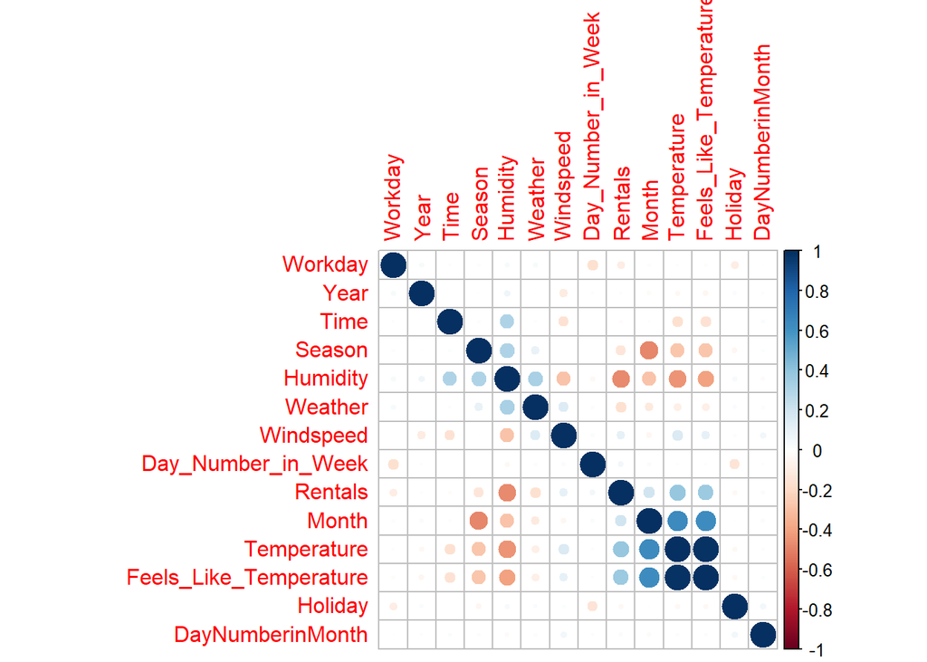

```
## Partial Least Squares
##
## 3841 samples
##    8 predictor
##
## No pre-processing
## Resampling: Bootstrapped (25 reps)
## Summary of sample sizes: 3841, 3841, 3841, 3841, 3841, 3841, ...
## Resampling results across tuning parameters:
##
##   ncomp  RMSE      Rsquared   MAE
##   1      756.2929  0.2689849  582.9008
##   2      746.5605  0.2875501  577.4127
##   3      744.3612  0.2917541  575.7991
##   4      744.0895  0.2922679  575.0832
##   5      743.8547  0.2927147  574.0325
##   6      743.0589  0.2942056  573.8476
##   7      742.5310  0.2952046  573.2735
##
## RMSE was used to select the optimal model using the smallest value.
## The final value used for the model was ncomp = 7.
```

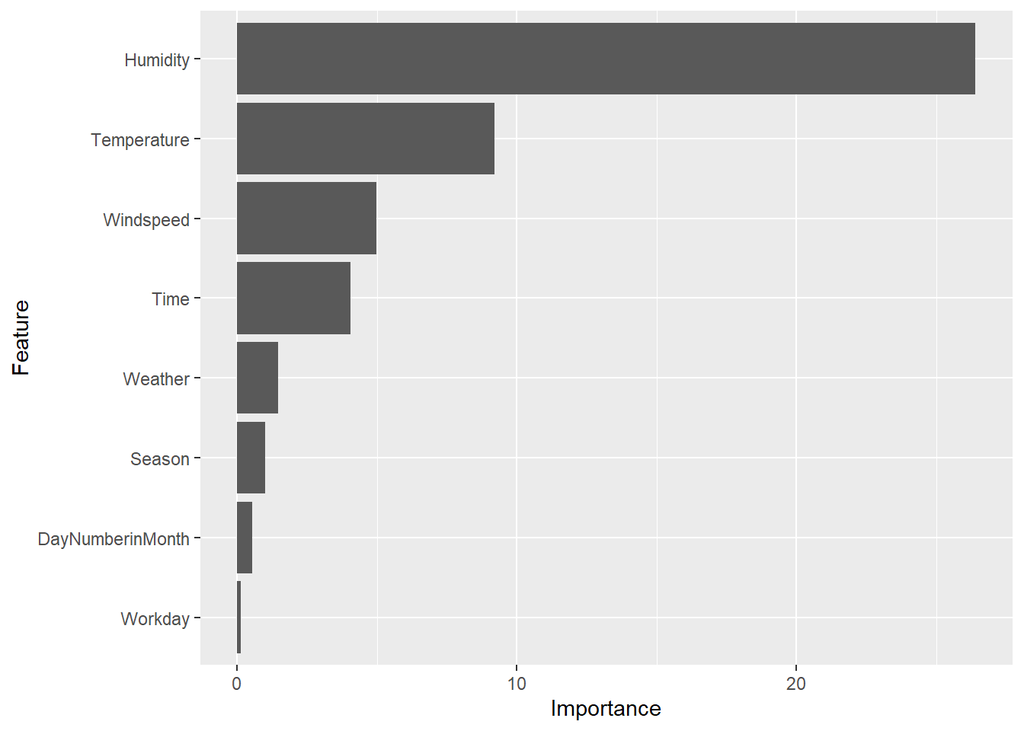

#Observation: From the above feature importance chart, we can see that the predictor “Humidity” is highly important followed by Temperature, Windspeed, and Time.

```
## Linear Regression
##
## 3841 samples
##    8 predictor
##
## No pre-processing
## Resampling: Cross-Validated (10 fold)
## Summary of sample sizes: 3457, 3457, 3456, 3456, 3457, 3458, ...
## Resampling results:
##
##   RMSE      Rsquared   MAE
##   740.9766  0.3005411  571.284
##
## Tuning parameter 'intercept' was held constant at a value of TRUE
```

```
##       RMSE      MAE
## 1 772.8357 590.5379
```

#Observation:

```
## [1] 772.8357
```

```
## [1] 590.5379
```

```
## Elasticnet
##
## 3841 samples
##    8 predictor
##
## Pre-processing: centered (8), scaled (8)
## Resampling: Cross-Validated (10 fold)
## Summary of sample sizes: 3457, 3457, 3457, 3456, 3458, 3456, ...
## Resampling results across tuning parameters:
##
##   fraction   RMSE      Rsquared   MAE
##   0.1000000  848.8713  0.2631763  688.1809
##   0.1642857  828.5586  0.2631763  667.8740
##   0.2285714  810.6571  0.2634203  649.3843
##   0.2928571  795.1084  0.2762945  633.0167
##   0.3571429  781.3304  0.2868036  618.3643
##   0.4214286  769.4851  0.2925068  605.3998
##   0.4857143  759.6636  0.2956406  594.1868
##   0.5500000  751.9458  0.2973451  585.3143
##   0.6142857  746.3973  0.2982267  578.6498
##   0.6785714  743.1159  0.2989474  574.2994
##   0.7428571  741.5173  0.3006598  572.0916
##   0.8071429  740.9004  0.3013995  571.3617
##   0.8714286  740.3920  0.3021461  571.0650
##   0.9357143  740.1371  0.3025349  570.9405
##   1.0000000  740.1330  0.3025273  571.0217
##
## Tuning parameter 'lambda' was held constant at a value of 0
## RMSE was used to select the optimal model using the smallest value.
## The final values used for the model were fraction = 1 and lambda = 0.
```

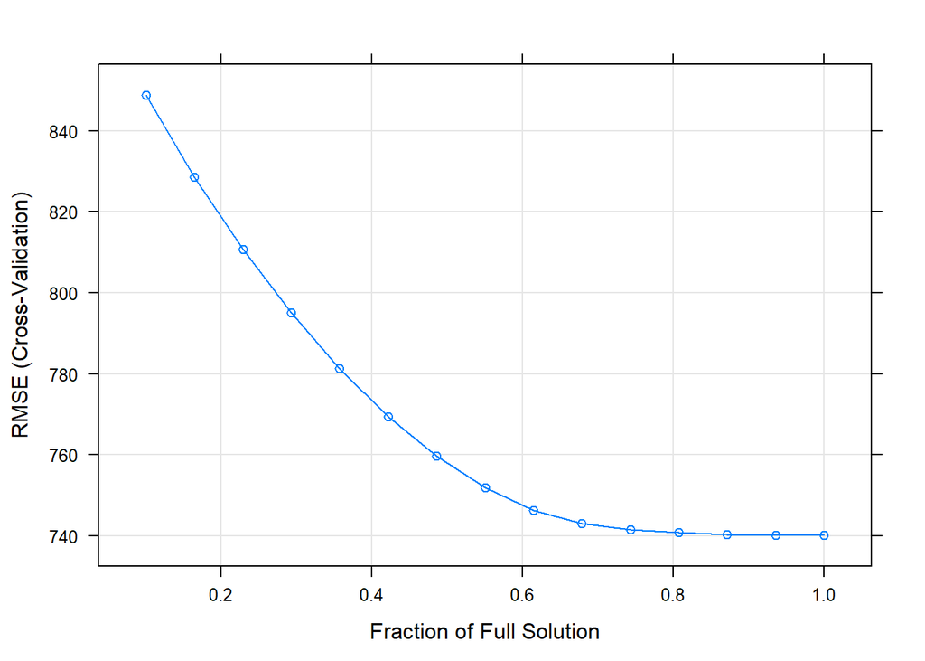

```
## Elasticnet
##
## 3841 samples
##    8 predictor
##
## Pre-processing: centered (8), scaled (8)
## Resampling: Cross-Validated (10 fold)
## Summary of sample sizes: 3457, 3457, 3457, 3456, 3458, 3456, ...
## Resampling results across tuning parameters:
##
##   fraction   RMSE      Rsquared   MAE
##   0.1000000  848.8713  0.2631763  688.1809
##   0.1642857  828.5586  0.2631763  667.8740
##   0.2285714  810.6571  0.2634203  649.3843
##   0.2928571  795.1084  0.2762945  633.0167
##   0.3571429  781.3304  0.2868036  618.3643
##   0.4214286  769.4851  0.2925068  605.3998
##   0.4857143  759.6636  0.2956406  594.1868
##   0.5500000  751.9458  0.2973451  585.3143
##   0.6142857  746.3973  0.2982267  578.6498
##   0.6785714  743.1159  0.2989474  574.2994
##   0.7428571  741.5173  0.3006598  572.0916
##   0.8071429  740.9004  0.3013995  571.3617
##   0.8714286  740.3920  0.3021461  571.0650
##   0.9357143  740.1371  0.3025349  570.9405
##   1.0000000  740.1330  0.3025273  571.0217
##
## Tuning parameter 'lambda' was held constant at a value of 0
## RMSE was used to select the optimal model using the smallest value.
## The final values used for the model were fraction = 1 and lambda = 0.
```

#Observation:

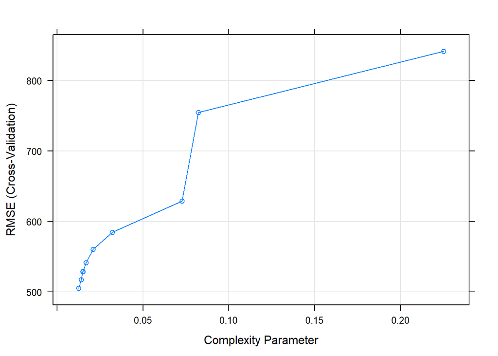

```
## CART
##
## 3841 samples
##    8 predictor
##
## No pre-processing
## Resampling: Cross-Validated (10 fold)
## Summary of sample sizes: 3457, 3457, 3456, 3456, 3457, 3458, ...
## Resampling results across tuning parameters:
##
##   cp          RMSE      Rsquared   MAE
##   0.01251918  504.9348  0.6751065  363.1634
##   0.01397541  517.2897  0.6588104  377.2009
##   0.01501005  528.7834  0.6434450  387.4055
##   0.01505233  528.7834  0.6434450  387.4055
##   0.01695402  541.3706  0.6261469  396.0669
##   0.02101454  560.4443  0.5988449  410.5766
##   0.03214655  584.5031  0.5641292  426.6160
##   0.07270155  628.6450  0.4953016  464.5023
##   0.08221999  754.6583  0.2706147  590.0795
##   0.22502253  841.6570  0.1892428  675.0812
##
## RMSE was used to select the optimal model using the smallest value.
## The final value used for the model was cp = 0.01251918.
```

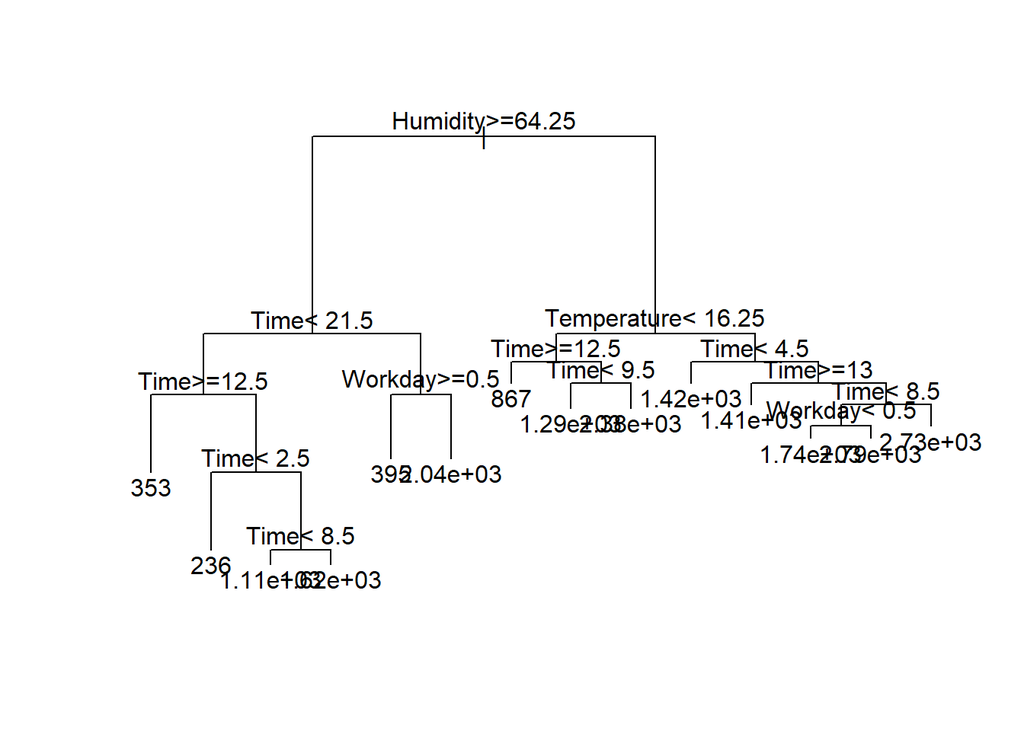

```
## [1] 521.2497
```

```
## [1] 368.6921
```

#Observation:

```
## [1] 544.6408
```

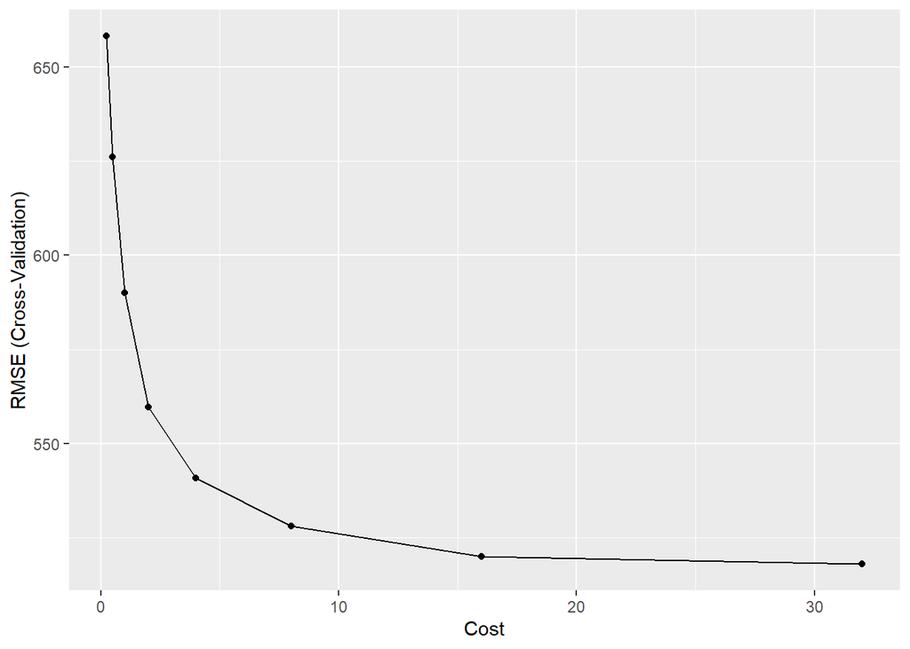

```
## Support Vector Machines with Radial Basis Function Kernel
##
## 3841 samples
##    8 predictor
##
## Pre-processing: centered (8), scaled (8)
## Resampling: Cross-Validated (10 fold)
## Summary of sample sizes: 3457, 3457, 3458, 3458, 3456, 3457, ...
## Resampling results across tuning parameters:
##
##   C      RMSE      Rsquared   MAE
##    0.25  658.1873  0.4715854  441.3572
##    0.50  626.1442  0.5204662  415.5985
##    1.00  590.0375  0.5730206  388.2926
##    2.00  559.6415  0.6146461  367.5555
##    4.00  540.8901  0.6380895  356.6272
##    8.00  528.0202  0.6527398  349.9181
##   16.00  519.9796  0.6616277  345.8807
##   32.00  517.9755  0.6627010  344.5726
##
## Tuning parameter 'sigma' was held constant at a value of 0.09318286
## RMSE was used to select the optimal model using the smallest value.
## The final values used for the model were sigma = 0.09318286 and C = 32.
```

#Observation:

MODEL PERFORMANCE COMPARSION

***Based on the above summary we can see that Regression tree model performed better compared to the rest if the models.Hence I decided to investigate further on the tree based model through appropriate tuning methods along with other feature engineering techniques.

Although demand prediction is the main exercise for this project but predicting rentals on hourly basis for any given day based on the given weather, season and weekday/weekend etc., this makes the problem somewhat DIFFICULT.